# Lab 4 - Checkpoint 4

Arnaldo Gualberto

27/05/2017

- **Há uma diferença significativa entre a popularidade de uma linguagem entre Sábado e Domingo?**
- **Há uma diferença significativa entre o número de desenvolvedores entre final de semana e dias da semana?**

Decidi utilizar a linguagem *python* para responder a primeira pergunta. Além disso, inicialmente eu acredito que haja uma diferença significativa na segunda pergunta, ao contrário da primeira.

# 0. Imports and Settings

```r
library(dplyr, warn.conflicts = FALSE)
library(ggplot2)
library(knitr)
library(lubridate, warn.conflicts = FALSE)
library(readr)
library(resample)
library(reshape2)
source('multiplot.R')

# Coloca todos os titulos dos gráficos centralizados
theme_update(plot.title = element_text(hjust=0.5))
```

# 1. Carregamento e limpeza dos dados

Primeiramente, vou carregar os dados e alterar o nome de suas colunas para facilitar o entendimento:

```r
dados_github <- read_csv("data/github-data.csv")
names(dados_github) <- c("extensao", "dia", "mes", "ano", "usuarios")

head(dados_github) %>% kable()
```

| extensao | dia | mes | ano | usuarios |
| --- | --- | --- | --- | --- |
| md | 18 | 2 | 2016 | 10279 |
| md | 17 | 2 | 2016 | 10208 |
| md | 27 | 1 | 2016 | 10118 |
| md | 16 | 2 | 2016 | 10045 |
| md | 26 | 1 | 2016 | 10020 |
| md | 21 | 3 | 2017 | 10015 |

Agora, vou criar duas novas colunas: uma com a data por completo e outra com o dia da semana correspondente:

```r
dados_all <- dados_github %>%
  mutate(data = ymd(paste(ano, mes, dia)), dia_da_semana = wday(data, label = T))

head(dados_all) %>% kable()
```

| extensao | dia | mes | ano | usuarios | data | dia_da_semana |
| --- | --- | --- | --- | --- | --- | --- |
| md | 18 | 2 | 2016 | 10279 | 2016-02-18 | Thurs |
| md | 17 | 2 | 2016 | 10208 | 2016-02-17 | Wed |
| md | 27 | 1 | 2016 | 10118 | 2016-01-27 | Wed |
| md | 16 | 2 | 2016 | 10045 | 2016-02-16 | Tues |
| md | 26 | 1 | 2016 | 10020 | 2016-01-26 | Tues |
| md | 21 | 3 | 2017 | 10015 | 2017-03-21 | Tues |

# 2. Análise Descritiva

Antes de responder as duas perguntas, vou efetuar algumas análises descritivas em cima dos dados que eu acredito que me ajudarão a responder as perguntas além de me ajudar a entender os dados. Logo, vou começar carregando os dados de python e github que vou utilizar para essa análise:

```r
dados_python <- dados_all %>% filter(extensao == "py" & (dia_da_semana == "Sat" | dia_da_semana == "Sun")) %>% droplevels()

summary(dados_python) %>% kable()
```

|  | extensao | dia | mes | ano | usuarios | data | dia_da_semana |
| --- | --- | --- | --- | --- | --- | --- | --- |
|  | Length:142 | Min. : 1.00 | Min. : 1.000 | Min. :2016 | Min. :1445 | Min. :2016-01-02 | Sun:71 |
|  | Class :character | 1st Qu.: 8.00 | 1st Qu.: 3.000 | 1st Qu.:2016 | 1st Qu.:2324 | 1st Qu.:2016-05-02 | Sat:71 |
|  | Mode :character | Median :16.00 | Median : 5.000 | Median :2016 | Median :2586 | Median :2016-09-03 | NA |
|  | NA | Mean :15.63 | Mean : 5.493 | Mean :2016 | Mean :2525 | Mean :2016-09-03 | NA |
|  | NA | 3rd Qu.:23.00 | 3rd Qu.: 8.000 | 3rd Qu.:2017 | 3rd Qu.:2770 | 3rd Qu.:2017-01-05 | NA |
|  | NA | Max. :31.00 | Max. :12.000 | Max. :2017 | Max. :3103 | Max. :2017-05-07 | NA |

```r
dados_all_fds <- dados_all %>% filter(dia_da_semana == "Sat" | dia_da_semana == "Sun")

summary(dados_all_fds) %>% kable()
```

|  | extensao | dia | mes | ano | usuarios | data | dia_da_semana |
| --- | --- | --- | --- | --- | --- | --- | --- |
|  | Length:3162 | Min. : 1.00 | Min. : 1.000 | Min. :2016 | Min. : 501 | Min. :2016-01-02 | Sun :1598 |
|  | Class :character | 1st Qu.: 8.00 | 1st Qu.: 2.000 | 1st Qu.:2016 | 1st Qu.: 813 | 1st Qu.:2016-04-24 | Mon : 0 |
|  | Mode :character | Median :16.00 | Median : 4.000 | Median :2016 | Median :1481 | Median :2016-09-04 | Tues : 0 |
|  | NA | Mean :15.57 | Mean : 5.373 | Mean :2016 | Mean :1776 | Mean :2016-09-02 | Wed : 0 |
|  | NA | 3rd Qu.:23.00 | 3rd Qu.: 8.000 | 3rd Qu.:2017 | 3rd Qu.:2168 | 3rd Qu.:2017-01-08 | Thurs: 0 |
|  | NA | Max. :31.00 | Max. :12.000 | Max. :2017 | Max. :7293 | Max. :2017-05-07 | Fri : 0 |
|  | NA | NA | NA | NA | NA | NA | Sat :1564 |

```r
dados_all_dds <- dados_all %>% filter(dia_da_semana != "Sat" & dia_da_semana != "Sun")

summary(dados_all_dds) %>% kable()
```

|  | extensao | dia | mes | ano | usuarios | data | dia_da_semana |
| --- | --- | --- | --- | --- | --- | --- | --- |
|  | Length:10640 | Min. : 1.00 | Min. : 1.000 | Min. :2016 | Min. : 501 | Min. :2016-01-01 | Sun : 0 |
|  | Class :character | 1st Qu.: 8.00 | 1st Qu.: 3.000 | 1st Qu.:2016 | 1st Qu.: 737 | 1st Qu.:2016-04-22 | Mon :2098 |
|  | Mode :character | Median :15.00 | Median : 5.000 | Median :2016 | Median : 1558 | Median :2016-08-26 | Tues :2200 |
|  | NA | Mean :15.47 | Mean : 5.443 | Mean :2016 | Mean : 2262 | Mean :2016-08-28 | Wed :2195 |
|  | NA | 3rd Qu.:23.00 | 3rd Qu.: 8.000 | 3rd Qu.:2016 | 3rd Qu.: 2896 | 3rd Qu.:2016-12-30 | Thurs:2125 |
|  | NA | Max. :31.00 | Max. :12.000 | Max. :2017 | Max. :10279 | Max. :2017-05-11 | Fri :2022 |
|  | NA | NA | NA | NA | NA | NA | Sat : 0 |

Para facilitar a visualização dessas informações, vamos analisar o boxplot de cada dado:

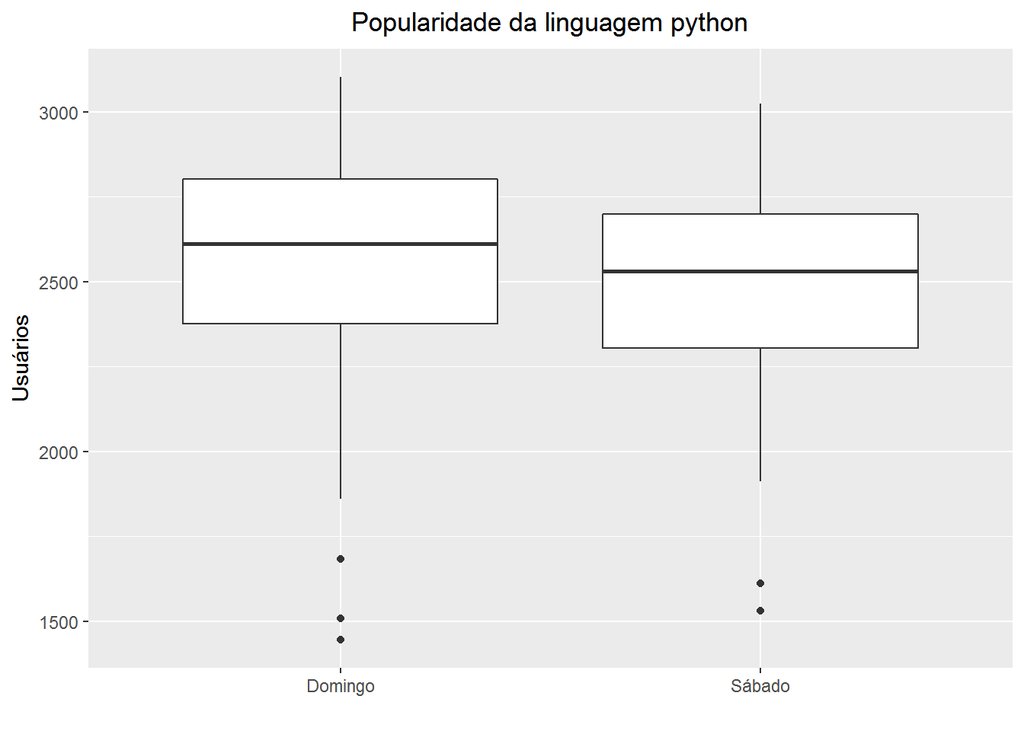

```r
dados_python %>%
  ggplot(aes(x = dia_da_semana, y =  usuarios, group = dia_da_semana)) +
  geom_boxplot() +
  ggtitle("Popularidade da linguagem python") +
  labs(x = "", y = "Usuários") +
  scale_x_discrete(labels = c("Sun"="Domingo", "Sat"="Sábado"))
```

O boxplot acima nos mostra a semelhança entre a quantidade de usuários que alteram arquivos python entre Sábado e Domingo. **A faixa de valores, o IQR e a mediana dos dados de Domingo são ligeiramente maiores quando comparados ao Sábado**.

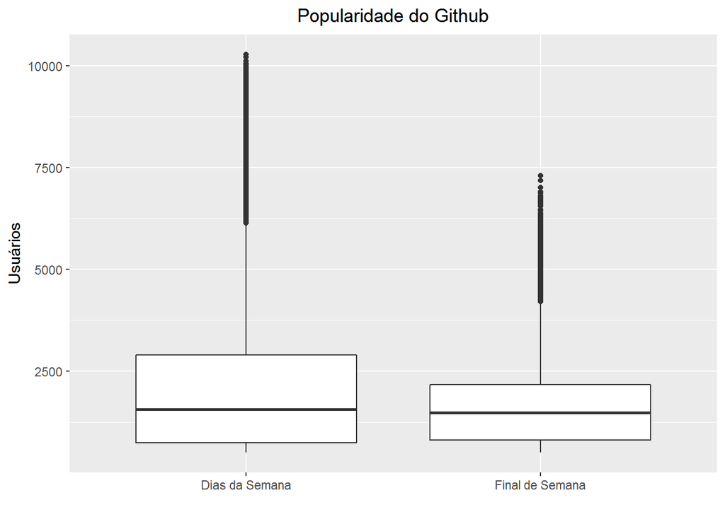

```r
ggplot() +
  geom_boxplot(data = dados_all_fds, aes(x = "Final de Semana", y = usuarios)) +
  geom_boxplot(data = dados_all_dds, aes(x = "Dias da Semana", y = usuarios)) +
  ggtitle("Popularidade do Github") +
  labs(x = "", y = "Usuários")
```

Já para os dados do github, **a principal diferença é a faixa de valores**, como mostrado anteriormente. **A IQR para os dias da semana também é maior em comparação ao fim de semana. Entretanto, a mediana dos dois boxplots são bem parecidas**.

Vale salientar que em ambos os boxplots mostrado a cima, os pontos definidos como outlier, ao meu ver, não representam realmente outliers nos nossos dados. Pois, seus valores são plausíveis para a quantidade de usuários da plataforma.

Agora, quero analisar a densidade da distribuição de usuários de ambos os dados. Vou começar analisando os dados da linguagem python:

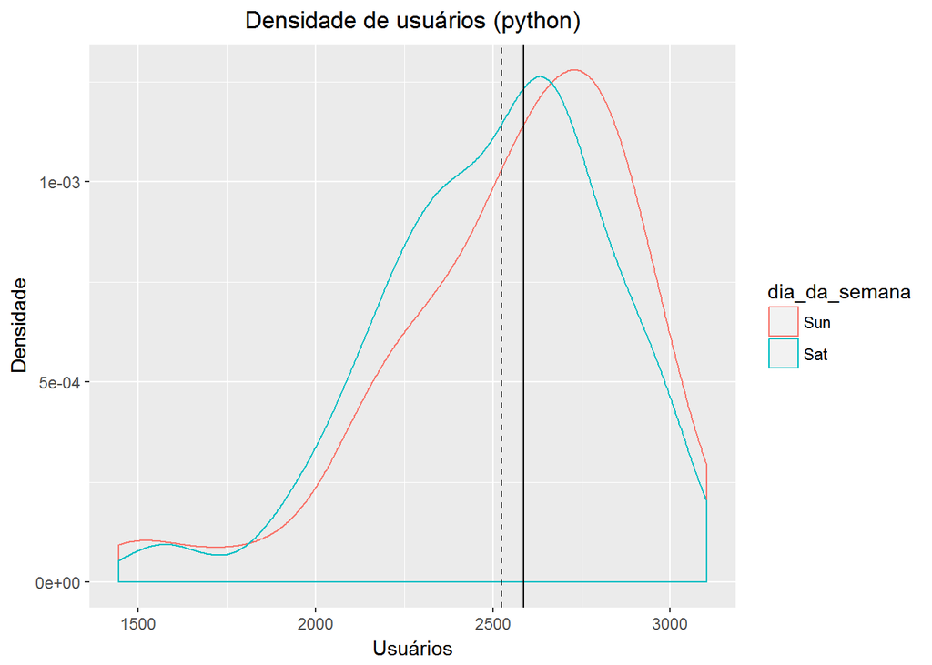

```r
dados_python %>%
  ggplot(aes(x=usuarios, group = dia_da_semana)) +
  geom_density(aes(color = dia_da_semana)) +
  geom_vline(xintercept = mean(dados_python$usuarios), linetype = "dashed") +
  geom_vline(xintercept = median(dados_python$usuarios)) +
  ggtitle("Densidade de usuários (python)") +
  labs(x = "Usuários", y = "Densidade")
```

Como serão essa distribuições nos dados do github?

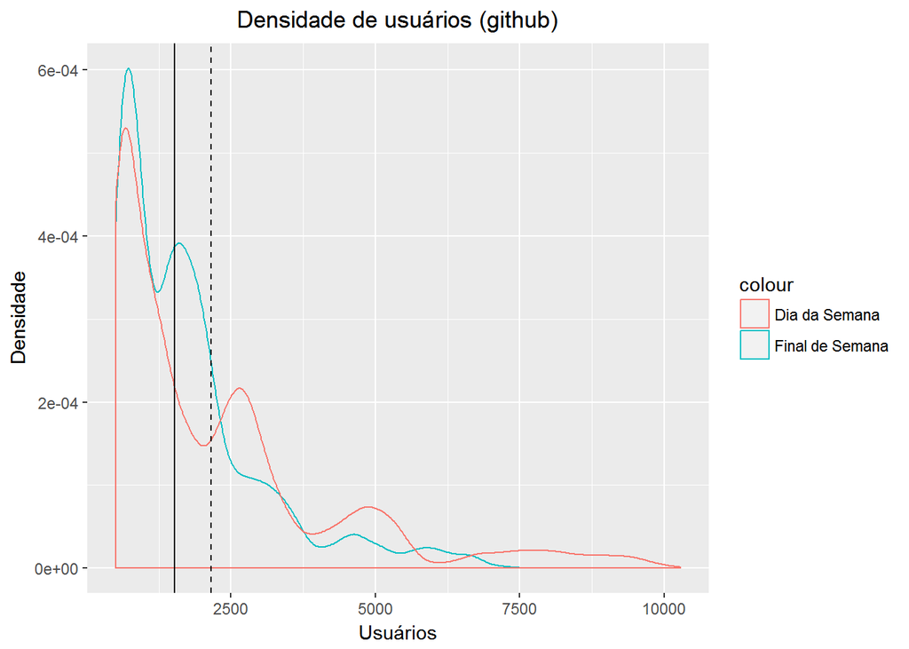

```r
ggplot() +
  geom_density(data = dados_all_fds, aes(x = usuarios, colour = "Final de Semana")) +
  geom_density(data = dados_all_dds, aes(x = usuarios, colour = "Dia da Semana")) +
  geom_vline(xintercept = mean(dados_all$usuarios), linetype = "dashed") +
  geom_vline(xintercept = median(dados_all$usuarios)) +
  ggtitle("Densidade de usuários (github)") +
  labs(x = "Usuários", y = "Densidade")
```

No caso do github, a distribuição de usuários nos dias da semana e durante o fim de semana também são, de certa forma, parecidas. No entanto, agora **as distribuições são concentradas à esquerda com cada longa à direita**. Ademais, também pode-se dizer que ambas as distribuições apresentam bimodalidade ou até trimodalidade. A média (linha vertical tracejada) e a mediana (linha vertical contínua) agora são mais distantes que no caso de python. Quando formos efetuar a inferência estatística, devemos levar isso em consideração.

Para finalizar a análise descritiva, quero analisar a mediana de usuários para os dados de cada uma das análises que vou efetuar.

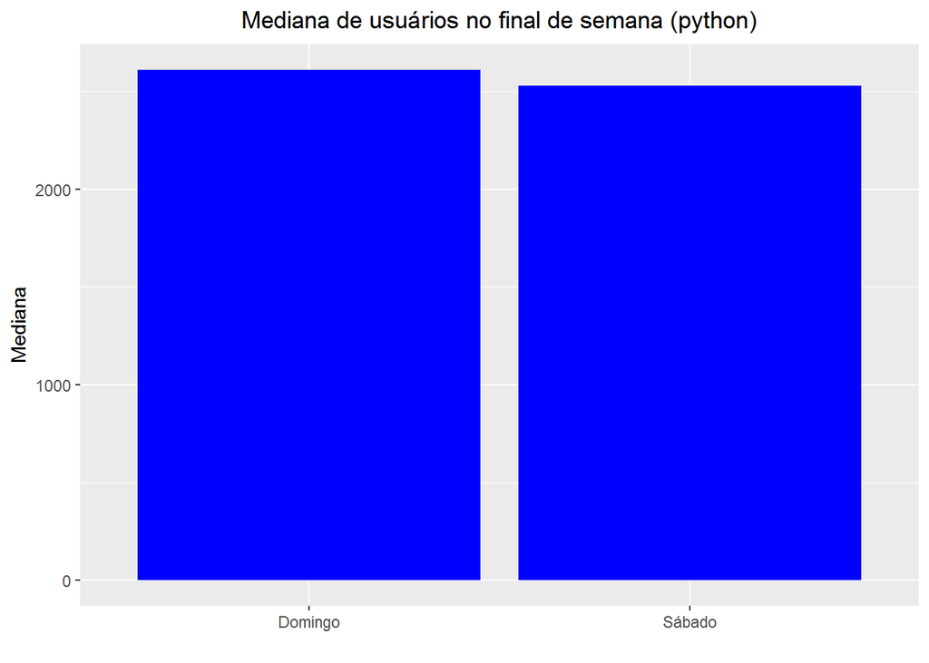

```r
dados_python %>%
  group_by(dia_da_semana) %>%
  summarise(total_usuarios = median(usuarios)) %>%
  ggplot(aes(x = dia_da_semana, y = total_usuarios)) +
  geom_bar(stat = "identity", fill = "blue") +
  ggtitle("Mediana de usuários no final de semana (python)") +
  labs(x = "", y = "Mediana") +
  scale_x_discrete(labels = c("Sun"="Domingo", "Sat"="Sábado"))
```

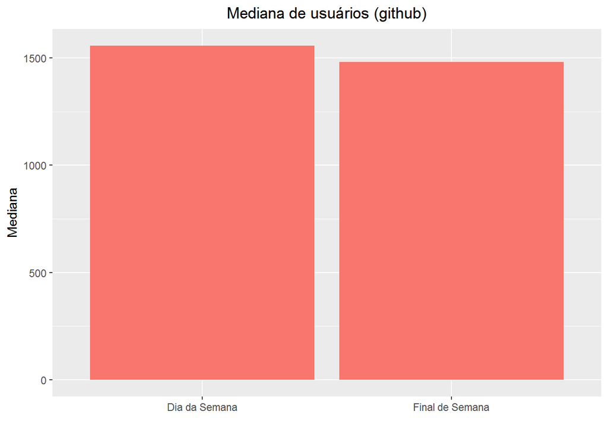

```r
ggplot() +
  geom_col(aes(x = "Final de Semana", y = median(dados_all_fds$usuarios), fill = "red")) +
  geom_col(aes(x = "Dia da Semana", y = median(dados_all_dds$usuarios), fill = "red")) +
  ggtitle("Mediana de usuários (github)") +
  labs(x = "", y = "Mediana") +
  theme(legend.position = "none")
```

Os gráficos de barra acima nos mostram que as medianas de usuários em cada gráfico são bem parecidas. Isso talvez demonstre que não há uma diferença significante entre as amostras. Vamos verificar isso na próxima seção.

# 3. Inferência estatística

Como os dados que temos representam apenas uma amostra da população, teremos de efetuar o *bootstrap* para estimar estatísticas da população, calcular os intervalos de confiança e, consequentemente, compará-las. Neste trabalho vamos estimar a mediana da população, uma vez que essa estatística é mais robusta em relação a média.

Em ambas as respostas das questões, **vamos calcular o intervalo de confiança para 95%**.

## 3.1 Há uma diferença significativa entre a popularidade de uma linguagem entre Sábado e Domingo?

A primeira inferência que vamos aplicar será para comparar a popularidade da linguagem python entre Sábado e Domingo. Nesse caso, queremos saber se há uma diferença significativa de popularidade de python entre Sábado e Domingo. Em outras palavras: **Será que python é mais popular no Sábado que no Domingo (ou vice-versa)? Se sim, quanto é essa diferença?**.

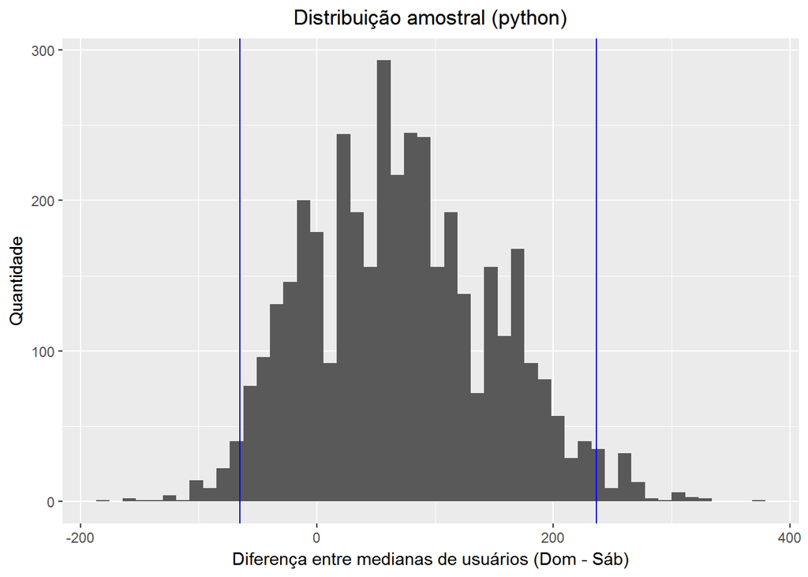

```r
mean.python <- bootstrap2(dados_python, median(usuarios), treatment = dia_da_semana, R = 4000, seed = 42)
ci.python <- mean.python %>% CI.percentile(probs = c(.025, .975))

mean.python$replicates %>%
  as.data.frame() %>%
  ggplot(aes(x = `median(usuarios): Sun-Sat`)) +
  geom_histogram(bins = 50) +
  geom_vline(xintercept = as.vector(ci.python)[1], color = "blue") +
  geom_vline(xintercept = as.vector(ci.python)[2], color = "blue") +
  ggtitle("Distribuição amostral (python)") +
  labs(x = "Diferença entre medianas de usuários (Dom - Sáb)", y = "Quantidade")
```

```r
ci.python
```

```
##                           2.5%   97.5%
## median(usuarios): Sun-Sat  -65 236.651
```

Pelo gráfico acima, podemos afirmar com 95% de confiança que **a diferença da mediana da popularidade de python entre Sábado e Domingo está entre [-65, 236.651]**. Ou seja, **a mediana de usuários alterando arquivos python no Domingo pode ser menor ou maior que no Sábado**.

Ambos os intervalos de confiança estão destacados em azul no gráfico. **Vale ressaltar que os intervalos de confiança mostrados estimam a diferença mediana da população**.

Vamos agora observar os intervalos de confiança na forma de barras de erro:

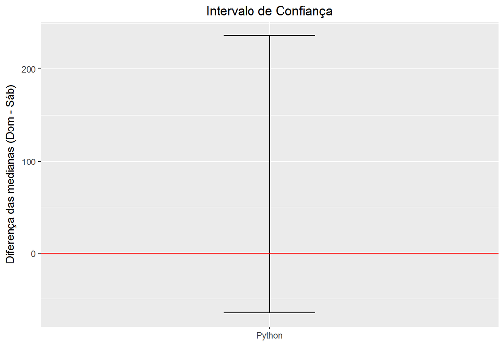

```r
ci.python %>%
  as.data.frame() %>%
  ggplot(aes(x = "Python", ymin = `2.5%`, ymax = `97.5%`)) +
  geom_errorbar(width = .2) +
  geom_hline(yintercept = 0, color = "red") +
  ggtitle("Intervalo de Confiança") +
  labs(x = "", y = "Diferença das medianas (Dom - Sáb)")
```

Pelo gráfico acima, uma vez que o intervalo de confiança cruza o valor zero por ampla margem, **NÃO há diferença significativa entre a popularidade da linguagem python entre Sábado e Domingo (com 95% de confiança)**. Isso significa que nem sempre a popularidade de python no Domingo é maior que no Sábado. Como dito anteriormente, esse resultado era esperado.

## 3.2 Há uma diferença significativa entre o número de desenvolvedores entre final de semana e dias da semana?

Vamos agora analisar se existe uma diferença significativa de desenvolvedores entre o final de semana e os dias da semana. Em outras palavras, agora queremos saber: **Será que a quantidade de desenvolvedores durante a semana no github é significantemente maior que nos finais de semana?**.

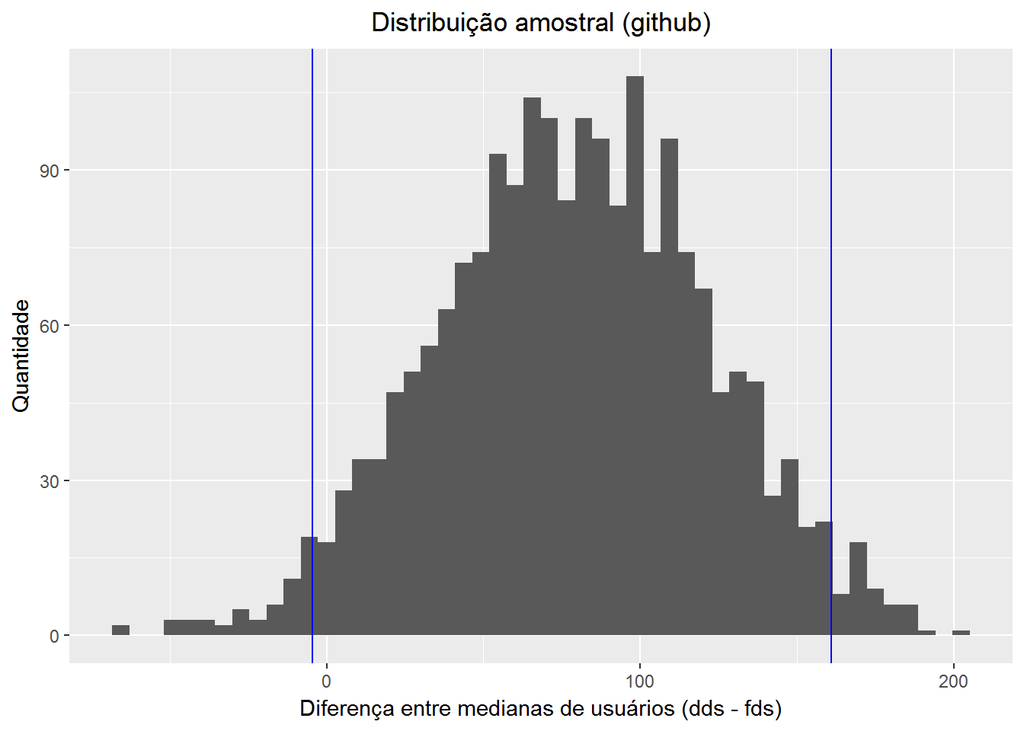

```r
mean.all <- bootstrap2(dados_all_dds, data2 = dados_all_fds, median(usuarios), R = 2000, seed = 42)
ci.all <- mean.all %>% CI.percentile(probs = c(.025, .975))

mean.all$replicates %>%
  as.data.frame() %>%
  ggplot(aes(x = `median(usuarios): dados_all_dds-dados_all_fds`)) +
  geom_histogram(bins = 50) +
  geom_vline(xintercept = as.vector(ci.all)[1], color = "blue") +
  geom_vline(xintercept = as.vector(ci.all)[2], color = "blue") +
  ggtitle("Distribuição amostral (github)") +
  labs(x = "Diferença entre medianas de usuários (dds - fds)", y = "Quantidade")
```

```r
ci.all
```

```
##                                                   2.5%    97.5%
## median(usuarios): dados_all_dds-dados_all_fds -4.54947 161.0495
```

Com 95% de confiança, podemos estimar que **a diferença entre a mediana da popularidade dos desenvolvedores durante a semana e o fim de semana deve estar entre [-4.54947, 161.0495]**. Novamente, o intervalo de confiança está destacado em linhas verticas azuis no gráfico.

Quando plotamos o intervalo de confiança na forma de barras de erro:

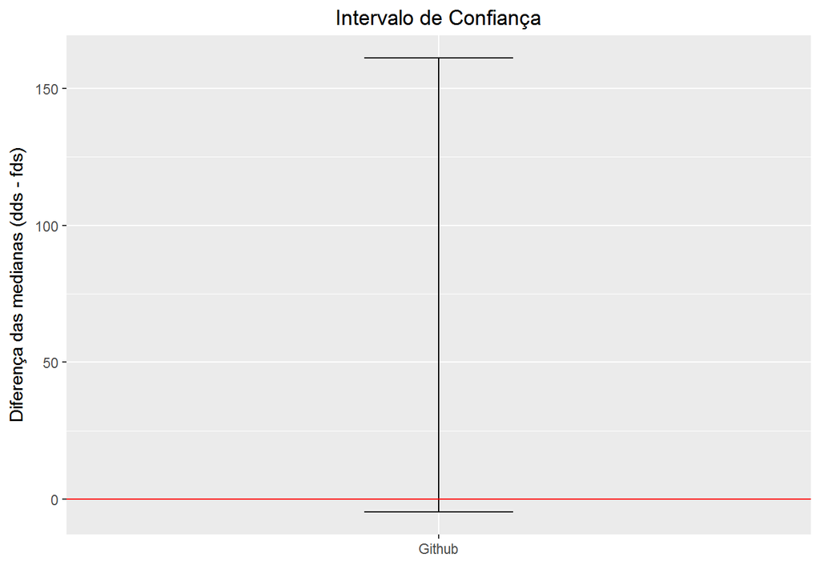

```r
ci.all %>%
  as.data.frame() %>%
  ggplot(aes(x = "Github", ymin = `2.5%`, ymax = `97.5%`)) +
  geom_errorbar(width = .2) +
  geom_hline(yintercept = 0, color = "red") +
  ggtitle("Intervalo de Confiança") +
  labs(x = "", y = "Diferença das medianas (dds - fds)")
```

Novamente, como o intervalo de confiança cruza o valor zero, **podemos afimar com 95% de confiança que não há uma diferença significativa entre a popularidade do github entre o fim de semana e os dias da semana**. Em geral, a quantidade mediana de desenvolvedores durante a semana é maior que no fim de semana, mas nem sempre. Dessa vez, o resultado obtido foi diferente do esperado.

Vale ressaltar que, como o intervalo de confiança cruzou o valor zero por uma pequena margem, podemos tentar diminuir o nível de confiança pra ver se podemos afirmar uma diferença significativa:

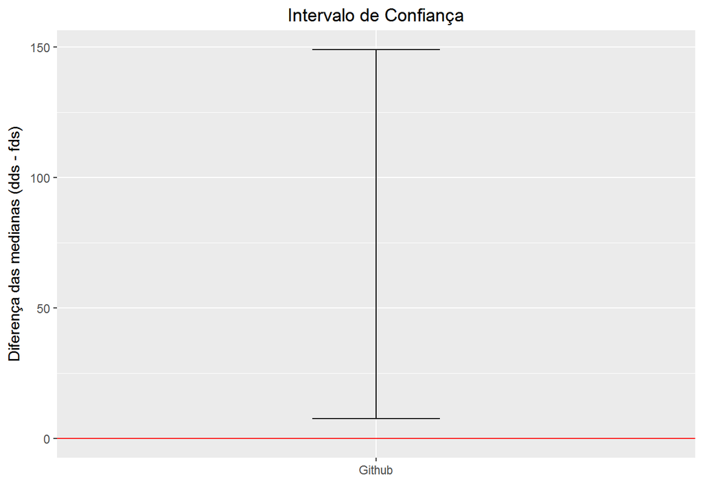

```r
ci.all_90 <- mean.all %>% CI.percentile(probs = c(.05, .95))

ci.all_90 %>%
  as.data.frame() %>%
  ggplot(aes(x = "Github", ymin = `5%`, ymax = `95%`)) +
  geom_errorbar(width = .2) +
  geom_hline(yintercept = 0, color = "red") +
  ggtitle("Intervalo de Confiança") +
  labs(x = "", y = "Diferença das medianas (dds - fds)")
```

Nesse caso, podemos afirmar com **90% de confiança que existe uma diferença significativa entre a mediana de desenvolvedores do github durante a semana e durante o fim de semana**.

# 4. Conclusões

- Com 95% de confiança, não há uma diferença significativa entre a popularidade de python aos sábados e domingos;
- Com 95% de confiança, não há uma diferença significativa entre a popularidade do github durante a semana e durante o fim de semana. No entanto, essa diferença é significativa com 90% de confiança.